## Report: act_report

- Create a **250-word-minimum written report** called "act_report.pdf" or "act_report.html" that communicates the insights and displays the visualization(s) produced from your wrangled data. This is to be framed as an external document, like a blog post or magazine article, for example.

# WeRateDogs Twitter Archive - Act Report

The project seeks to put in practice all what has been learnt in the Data Wrangling section of this Udacity Nanodegree program. The main goal is to wrangle the WeRateDogs twitter data to draw insights and create visualizations from the data. WeRateDogs is a twitter account that rates people's dogs with humourous comment about the dog.

I was also able to draw some insights and create visualizations from the wrangled data.

After wrangling the data, I went on to draw some insights from the data.

1.The three most popular dog Names are Lucy, Charlie and olive

2.The most retweeted tweet is the tweet with id of 744234799360020481

3.There is a positive correlation between Retweets and Favourites

### Insight 1:

The three most popular dog Names are Lucy, Charlie and olive

### Insight 2:

The most retweeted tweet is the tweet with id of 744234799360020481. This tweet was made on the 18th of June 2016 and it was liked 131075 times and retweeted 79515 times.

### Insight 3:

There is a positive correlation between Retweets and Favourites

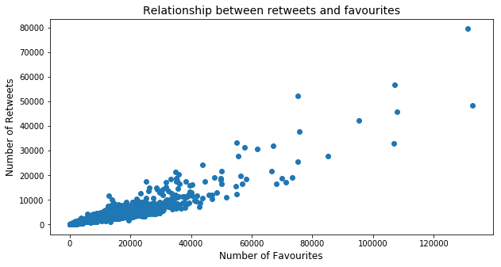

The scatter plot above depicts that there is a positive correlation between Retweets and Favorites but since there is no statistical operation performed here, we can't be certain.

[figure not shown]

### Limitation:

The missing records in the image predictions file and JSON file may affect the insights drawn and the visulaizations created.